# Probabilità continua

R. Sirovich & L. Federici

## Esercizio

#### Importante

Approssimate, se necessario, i risultati alla **quarta cifra decimale**.

La variabile aleatoria $X$ ha funzione di distribuzione (CDF) rappresentata dalla linea blu nella seguente figura. La variabile aleatoria $Y$ ha funzione di distribuzione (CDF) rappresentata dalla linea rossa nella seguente figura.

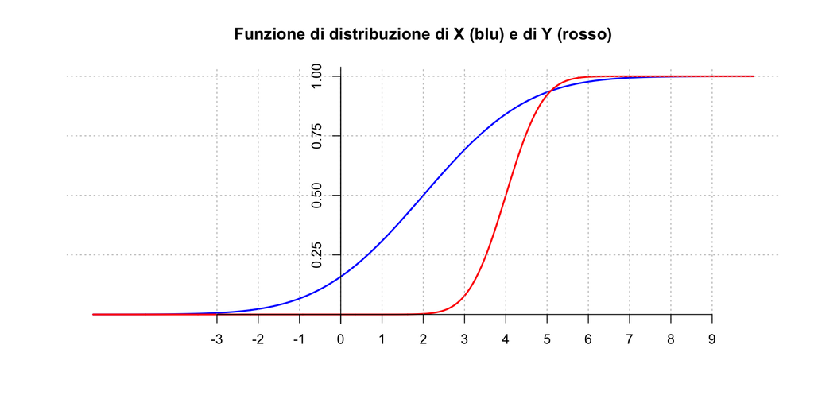

1. $X$ ha valor medio ##ANSWER1## e $Y$ ha valor medio ##ANSWER2##
2. Seleziona la risposta corretta ##ANSWER3##
- E(X) > E(Y)
- E(X) < E(Y)
- E(X) = E(Y)
3. Seleziona la risposta corretta ##ANSWER4##
- Var(X) > Var(Y)
- Var(X) < Var(Y)
- Var(X) = Var(Y)
4. Seleziona la risposta corretta ##ANSWER5##
- P(3 < X < 4) > P(3 < Y < 4)
- P(3 < X < 4) < P(3 < Y < 4)
- P(3 < X < 4) = P(3 < Y < 4)
5. Quale delle seguenti affermazioni si può dedurre dall’osservazione del grafico? ##ANSWER6##
- Var(Y) = 0.5
- Var(Y) = 2
- P(Y < 3) < 0.75
- Nessuna delle opzioni risulta corretta

## Esercizio

#### Importante

- Approssimate, se necessario, i risultati alla **quarta cifra decimale**.

La variabile aleatoria $X$ ha densità rappresentata dalla linea blu nella seguente figura

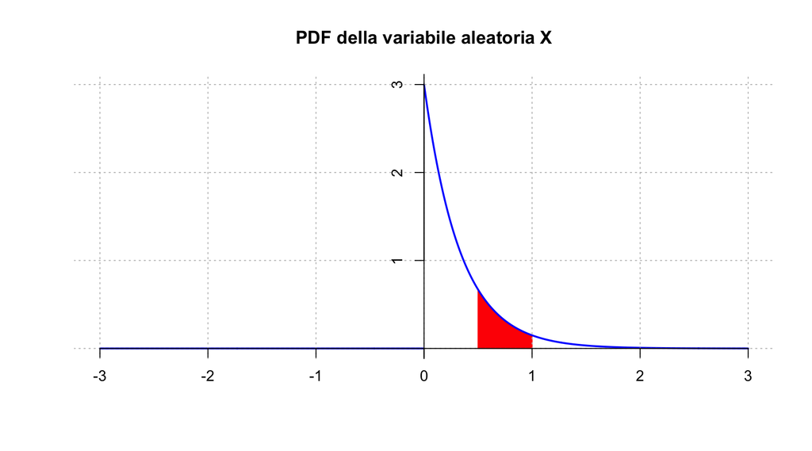

1. $X$ ha valor medio ##ANSWER1##
2. $X$ ha deviazione standard ##ANSWER2##
3. La probabilità rappresentata dall’area della porzione di grafico in rosso è pari a ##ANSWER3##
4. E$(3X^2)=$ ##ANSWER4##
5. Var$(3X)=$ ##ANSWER5##

#### Soluzione

1. La v.a. ha distribuzione Esponenziale, con parametro $\lambda$ pari alla coordinata y del punto in cui la densità tocca l’asse delle y. $X$ ha quindi valor medio pari ad $1/\lambda$, ovvero 0.3333.
2. $X$ ha deviazione standard pari a $1/\lambda$ quindi 0.3333
3. La probabilità rappresentata in rosso è pari a 0.1733:

   ```r
    pexp(1,lambda) - pexp(0.5,lambda)
   ```

## Esercizio

#### Importante

Approssimate, se necessario, i risultati alla **quarta cifra decimale**.

Il boschetto davanti a casa tua conta $14$ alberi. Ciascuno di essi ha durata di vita $X$, con distribuzione Esponenziale di media $50$ anni. Si considerino le durate di vita dei diversi alberi indipendenti.

1. Con quale probabilità un albero vive più di $30$ anni? ##ANSWER1##
2. Con quale probabilità un albero vive più di $30$ anni, sapendo che è vivo da $15$ anni? ##ANSWER2##
3. Con quale probabilità tra $30$ anni il boschetto davanti a casa tua avrà meno ($<$) della metà degli alberi che ha oggi? ##ANSWER3##

#### Soluzione

1. Utilizzando la funzione di distribuzione esponenziale di parametro $\lambda = 1/E(X)$, si ottiene che
   $$\mathbb P(X>30)=1-\mathbb
   P(X\leq 30)= 1 - F_{X}(30)= 0.5488$$
   Allora si utilizzerà il comando R con media=50

   ```r
    1 - pexp(30,rate = 1/media)
   ```

2. La probabilità che l’albero viva più di 30 anni sapendo che ne ha già più di 15 è data da
   $$\mathbb
   P(X>30|X>15)=\frac{\mathbb P(\{X>30\}\cap\{X>15\})}{\mathbb
   P(X>15)}=\frac{\mathbb P(X>30)}{\mathbb P(X>15)}$$
   e come prima si procede calcolando

   ```r
     (1 - pexp(30,rate = 1/media))/(1 - pexp(15,rate = 1/media))
   ```

   In alternativa possiamo usare la proprietà di assenza di memoria ovvero:
   $$\mathbb P(X>30|X>15)=\mathbb
   P(X>30-15) = \mathbb P(X>15).$$
3. La probabilità che un albero sia vivo dopo 30 anni è $p=1-\mathbb P(X\leq 30)=0.5488$. La probabilità che meno della metà degli alberi sia vivo dopo 30 anni si calcola con una binomiale $Y$ di parametri $n=14$ e $p$, che conta il numero di alberi vivi tra 30 anni sui 14 presenti oggi. Allora la risposta è data da
   $$\mathbb P(Y < \frac{14}{2}) = \mathbb P(Y <
   7) =\mathbb P(Y \leq 6)=0.2641$$
   e usiamo il comando R

   ```r
     pbinom(6,14,p)
   ```

## Esercizio

#### Importante

Approssimate, se necessario, i risultati alla **quarta cifra decimale**.

In un giorno lavorativo, passi davanti allo schermo del pc un tempo distribuito come una variabile aleatoria uniforme tra $5$ e $7$ ore. Si considerino i tempi di permanenza davanti al pc in giorni diversi indipendenti.

1. Con quale probabilità oggi (giorno lavorativo) starai al pc più di $6$ ore? ##ANSWER1##
2. Con quale probabilità oggi (giorno lavorativo) starai al pc più di $6$ ore se sono già $4$ ore che lavori a pc? ##ANSWER2##
3. Nei $5$ giorni lavorativi della settimana, mediamente quante ore stai davanti al pc? ##ANSWER3##
4. La probabilità che il numero di giorni (sui $5$ lavorativi) nei quali starai a pc più di $6$ ore sia superiore ($>$) a $2$ è pari a ##ANSWER4##

#### Soluzione

Chiamiamo X la variabile aleatoria che resitituisce il tempo passato al pc in un giorno lavorativo. X è una variabile aleatoria con distribuzione uniforme tra $5$ e $7$ ore, ovvero ha densità (PDF):

$$\begin{equation*}
f(x) = \frac{1}{b - a} \; \text{per } a \le x \le b
\end{equation*}$$

con a=$5$ e b=$7$. La funzione di distribuzione cumulata (CDF) è:

$$\begin{equation*}
P(X \leq y) = F_X(y) = \int_{0}^{y} f(x) dx
\end{equation*}$$

Si può calcolare $F_X(y)$ su R utilizzando il seguente comando:

```r
    punif(y,a,b)
```

1. La probabilità che oggi (giorno lavorativo) starai al pc più di $6$ ore è:

$$\begin{equation*}
P(X \geq 6) = 1-F_X(6) = 1 - \text{punif}(6,5,7) = 0.5
\end{equation*}$$

2. La probabilità con cui oggi (giorno lavorativo) starai al pc più di $6$ ore se sono già $4$ ore che lavori a pc è data da:

$$\begin{equation*}
P(X \geq 6|X \geq 4) = \frac{P(X \geq 6,X \geq 4)}{P(X \geq 4)} =
\frac{P(X \geq 6)}{P(X \geq 4)} =
\frac{1 - F_X(6)}{1 - F_X(4)} = 0.5
\end{equation*}$$

## Esercizio

#### Importante

Approssimate, se necessario, i risultati alla **quarta cifra decimale**.

Un lampadario monta $5$ lampadine. Ciascuna ha durata di vita $X$, con distribuzione Esponenziale di media $150$. Si considerino le durate di vita delle diverse lampadine indipendenti.

1. Con quale probabilità una lampadina dura più di $150$ ore? ##ANSWER1##
2. Con quale probabilità una lampadina dura più di $500$ ore, sapendo che è già stata accesa $150$ ore? ##ANSWER2##
3. La varianza del tempo di vita di una lampadina è pari a ##ANSWER3##
4. Con quale probabilità dopo $150$ ore funzionerà una sola lampadina? ##ANSWER4##

#### Soluzione

Sia $X$ la variabile aleatoria che resitituisce la durata di vita della lampadina. X è una variabile aleatoria con distribuzione esponenziale, ovvero ha densità (PDF):

$$\begin{equation*}
f(x) = \lambda e^{-\lambda x}, \; x \geq 0
\end{equation*}$$

con $\lambda = \frac{1}{150}$ essendo $\mathbb{E}(X) = \frac{1}{\lambda} = 150$. La funzione di distribuzione cumulata (CDF) è data da:

$$\begin{equation*}
P(X \leq y) = F_X(y) = \int_{0}^{y} f(x) dx
\end{equation*}$$

Si può calcolare $F_X(y)$ su R utilizzando il seguente comando:

```r
  pexp(y,lambda)
```

1. La probabilità che una lampadina duri più di $150$ ore è:

$$\begin{equation*}
P(X \geq 150) =
1 - P(X \leq 150) =
1 - F_X(150) =
1 - \text{pexp}(150,\frac{1}{150}) =
0.3679
\end{equation*}$$

2. La probabilità che una lampadina duri più di $500$ ore, sapendo che è già stata accesa $150$ ore è:

$$\begin{align*}
&P(X \geq 500|X \geq 150) =
\frac{P(X \geq 500,X \geq 150)}{P(X \geq 150)} =
\frac{P(X \geq 500)}{P(X \geq 150)} = \\
&= \frac{1 - P(X \leq 500)}{1 - P(X \leq 150)} =
\frac{1 - \text{pexp}(500,\frac{1}{150})}{1 -
\text{pexp}(150,\frac{1}{150})} =
0.097
\end{align*}$$
In alternativa possiamo usare la proprietà di assenza di memoria ovvero:
$$\mathbb
P(X>500|X>150)=\mathbb P(X>500-150) = \mathbb
P(X>350).$$

3. La varianza del tempo di vita di una lampadina è pari a:

$$\begin{equation*}
Var(X) = \frac{1}{\lambda^2} = \frac{1}{\frac{1}{150^2}} = 2.25\times
10^{4}
\end{equation*}$$

4. La probabilità che dopo $150$ ore funzionerà una sola lampadina posso riformularla come risultato di $5$ prove ripetute di tipo bernoulliano (una prova per ogni lampadina presente sul lampadario). Definiamo $Y$ come il numero di lampadine ancora funzionanti dopo $150$ ore. Quindi $Y \sim Binomiale(5,p)$ dove $p$ è la probabilità che la lampadina rimanga accesa dopo 150 ore, per cui $p=P(X \geq 150)$. Per cui possiamo calcolare $P(Y=1)$ come:

$$\begin{align*}
&\text{lambda = 1 /} 150\\
&\text{psucc = 1 - pexp(}150\text{,lambda)}\\
&\text{dbinom(1,}5\text{,psucc)}
\end{align*}$$
Ottenendo quindi $P(Y=1) = 0.2937$

## Esercizio

#### Importante

Approssimate, se necessario, i risultati alla **quarta cifra decimale**.

Hai appena preso un cucciolo di cane. Lo porti fuori $4$ volte al giorno e la durata (in minuti) della passeggiata è descritta da una variabile aleatoria Esponenziale di parametro $\lambda = 0.04$. Si considerino le durate delle diverse passeggiate indipendenti.

1. Con quale probabilità una passeggiata dura meno di $45$ minuti? ##ANSWER1##
2. Con quale probabilità una passeggiata dura meno di $45$ minuti, sapendo che sei a spasso da $41$ minuti? ##ANSWER2##
3. Mediamente quanti minuti stai a passeggio con il cucciolo ogni giorno? ##ANSWER3##
4. Con quale probabilità oggi farai almeno ($\geq$) $2$ passeggiate più corte di $45$ minuti? ##ANSWER4##

#### Soluzione

Sia $X$ la variabile aleatoria che resitituisce la durata della passeggiata con il cucciolo. $X$ è una variabile aleatoria esponenziale di parametro $\lambda = 0.04$, dunque ha densità (PDF):

$$\begin{equation*}
f(x) = \lambda e^{-\lambda x}, \; x \geq 0
\end{equation*}$$

La funzione di distribuzione cumulata (CDF) è:

$$\begin{equation*}
P(X \leq y) = F_X(y) = \int_{0}^{y} f(x) dx
\end{equation*}$$

Possiamo calcolare $F_X(y)$ su R utilizzando il seguente comando:

```r
  pexp(y,lambda)
```

1. La probabilità che una passeggiata duri meno di $45$ minuti è:

$$\begin{equation*}
P(X \leq 45) = F_X(45)= \text{pexp}(45,0.04) = 0.8347
\end{equation*}$$

## Esercizio

#### Importante

Approssimate, se necessario, i risultati alla **quarta cifra decimale**.

Hai un allevamento di Labrador Retriever. Il peso, a 2 mesi dalla nascita, dei cuccioli del tuo allevamento è distribuito come una variabile aleatoria normale di media $6.5$ Kg e di deviazione standard $0.6$ Kg. Si considerino i pesi alla nascita dei diversi cuccioli indipendenti.

1. Con quale probabilità uno dei cuccioli del tuo allevamento, a due mesi, pesa meno di $5.8$ Kg? ##ANSWER1##
2. Con quale probabilità i cuccioli del tuo allevamento, a due mesi, hanno un peso compreso tra $5.8$ e $7.7$? ##ANSWER2##
3. Entro quale valore di peso trovi il $19\%$ dei cuccioli del tuo allevamento che pesano meno a due mesi? ##ANSWER3##
4. Con l’ultima cucciolata sono nati $5$ cuccioli. Con quale probabilità al più ($\leq$) $4$ di questi cuccioli peseranno meno di $5.8$ Kg a due mesi? ##ANSWER4##

#### Soluzione

Sia $X$ la variabile aleatoria che resitituisce il peso dei cuccioli. $X$ è una variabile aleatoria normale di media $\mu = 6.5$ Kg e deviazione standard $\sigma = 0.6$ Kg. La sua densità (PDF) è:

$$\begin{equation*}
f(x) = \frac{1}{\sqrt{2\pi \sigma^2} } e^{-\frac{(x-\mu)^2}{2\sigma^2}}
\end{equation*}$$

La funzione di distribuzione cumulata (CDF) invece è data da:

$$\begin{equation*}
P(X \leq y) = F_X(y) = \int_{0}^{y} f(x) dx
\end{equation*}$$

Si può calcolare $F_X(y)$ su R utilizzando il seguente comando:

```r
  pnorm(y,mean,sd)
```

1. La probabilità che uno dei cuccioli dell’allevamento pesi meno di $5.8$ Kg é:

$$\begin{equation*}
P(X \leq 5.8) = F_X(5.8) = \text{pnorm}(5.8,6.5,0.6) = 0.1217
\end{equation*}$$

2. La probabilità che i cuccioli del tuo allevamento, a due mesi, abbiano un peso compreso tra $5.8$ e $7.7$ è:

$$\begin{equation*}
P(5.8\leq X \leq 7.7) = F_X(7.7) - F_X(5.8) = \text{pnorm}(7.7,6.5,0.6)
- \text{pnorm}(5.8,6.5,0.6) = 0.8556
\end{equation*}$$

3. Il valore di peso $y$ entro cui trovi il $19\%$ dei cuccioli del tuo allevamento possiamo riscriverlo come:
   $$\begin{equation*}
   P(X \leq y) = F_X(y) = 0.19
   \end{equation*}$$
   e $y$ lo possiamo calcolare usando la funzione:
   $$\begin{align*}
   \text{y = qnorm(} 0.19, 6.5,0.6)
   \end{align*}$$
   e otteniamo $y = 5.9733$.
4. Con l’ultima cucciolata sono nati $5$ cuccioli. La probabilità che al più ($\leq$) $4$ di questi cuccioli pesino meno di $5.8$ Kg si può riformulare come risultato di $5$ prove ripetute di tipo bernoulliano (una prova per ogni cucciolo nato). Definiamo $Y$ come il numero di cuccioli più leggeri di $5.8$ Kg. Dunque $Y \sim Binomiale(5,p)$ dove $p$ è la probabilità che il cucciolo pesi meno di $5.8$ Kg per cui $p=P(X \leq 5.8)$. Per cui possiamo calcolare $P(Y \leq 4)$ come:
   $$\begin{align*}
   &\text{> psucc = pnorm(}5.8,6.5,0.6)\\
   &\text{> pbinom(}4,5\text{, psucc)}
   \end{align*}$$
   Ottenendo quindi $P(Y \leq 4) = 1$.

## Esercizio

#### Importante

Approssimate, se necessario, i risultati alla **quarta cifra decimale**.

Ti piace molto camminare e ogni sabato fai una passeggiata. La durata delle tue passeggiate del sabato è descritta da una variabile aleatoria esponenziale, con media pari a $310$ minuti nelle giornate di sole e media pari a $270$ minuti nelle giornate senza sole.

La tua esperienza ti dice che c’è il sole il $40\%$ dei sabati.

1. Con quale probabilità una passeggiata dura meno di $260$ minuti? ##ANSWER1##
2. Con quale probabilità una passeggiata dura meno di $260$ minuti, sapendo che sei a spasso da $226$ minuti? ##ANSWER2##

Supponi che le durate delle tue passeggiate in sabati diversi siano indipendenti.

3. Con quale probabilità farai almeno ($\geq$) $8$ passeggiate più corte di $260$ minuti su $11$ sabati diversi? ##ANSWER3##

#### Soluzione

Sia $X$ la variabile aleatoria che indica la durata media delle passeggiate. Sappiamo che $X$ è una v.a. esponenziale, dunque ha densità (PDF):

$$\begin{equation*}
f(x) = \lambda e^{-\lambda x}, \; x \geq 0
\end{equation*}$$

dove $\lambda$ è pari all’inverso del valor medio, e quindi, in questo caso:

$$\begin{equation*}
\lambda = \begin{cases} 1/310 = 0.0032 \quad \text{se c'è il
sole}\\
1/270 = 0.0037 \quad \text{se non c'è il sole}.
\end{cases}
\end{equation*}$$

La funzione di distribuzione cumulata (CDF) è:

$$\begin{equation*}
P(X \leq y) = F_X(y) = \int_{0}^{y} f(x) dx
\end{equation*}$$

Possiamo calcolare $F_X(y)$ su R utilizzando il seguente comando:

```r
  pexp(y,lambda)
```

Inoltre dal testo sappiamo che la probabilità che ci sia il sole è pari a $0.4$, quella che non ci sia è data da $1- 0.4 = 0.6$.

## Esercizio

#### Importante

- Approssimate, se necessario, i risultati alla **quarta cifra decimale**.

La variabile aleatoria $X$ ha densità rappresentata dalla linea blu nella seguente figura. La variabile aleatoria $Y$ ha densità rappresentata dalla linea rossa nella seguente figura.

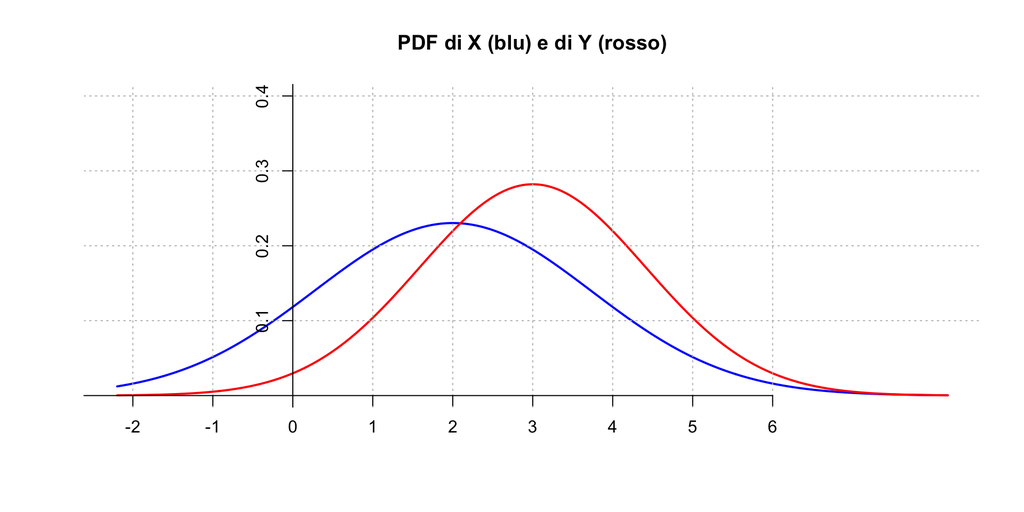

1. $X$ ha valor medio ##ANSWER1##
2. Seleziona la risposta corretta ##ANSWER2##
- E(X) > E(Y)
- E(X) < E(Y)
- E(X) = E(Y)
3. Seleziona la risposta corretta ##ANSWER3##
- Var(X) > Var(Y)
- Var(X) < Var(Y)
- Var(X) = Var(Y)
4. Seleziona la risposta corretta ##ANSWER4##
- P(3 < X < 5) > P(3 < Y < 5)
- P(3 < X < 5) < P(3 < Y < 5)
- P(3 < X < 5) = P(3 < Y < 5)
5. E$(4X-5)$ è pari a ##ANSWER5##
6. Var$(4X-5)$ è pari a ##ANSWER6##
- 4Var(X)
- 4Var(X)+5
- 4Var(X)-5
- Nessuna delle opzioni risulta corretta

#### Soluzione

1. In una distribuzione gaussiana il valor medio corrisponde al valore con probabilità massima. Osservando il grafico si deduce che $X$ ha valor medio uguale a 2.
2. Per lo stesso motivo si deduce che il valor medio di $Y$ è pari a 3 e dunque , E(X) < E(Y), .
3. La varianza di una distribuzione gaussiana è proporzionale all’ampiezza della campana che si ottiene graficando la PDF. Di conseguenza, confrontando le ampiezze dei due grafici si deduce che Var(X) > Var(Y), , .
4. Calcolare la probabilità che una variabile aleatoria sia compresa tra due valori corrisponde a calcolare l’integrale della PDF della v.a. tra quei due valori. Da questo si deduce, andando a confrontare l’area sottesa dal grafico blu e dal grafico rosso tra 3 e 5, che , P(3 < X < 5) < P(3 < Y < 5), .
5. Sfrutando la linearità del valor medio si ottiene $\mathbb{E}(4X-5) = 4\mathbb{E}(X)-\mathbb{E}(5)$. Ora ricordando che il valor medio di una costante è pari alla costante stessa, si ha che $\mathbb{E}(4X-5)=4 \mathbb{E}(X)-5=$ 3.
6. Ricordando che vale $Var(aX)=a^2Var(X)$ si deduce che nessuna delle opzioni risulta corretta.

## Esercizio

#### Importante

Approssimate, se necessario, i risultati alla **quarta cifra decimale**.

La variabile aleatoria $X$ ha densità rappresentata dalla linea blu nella seguente figura

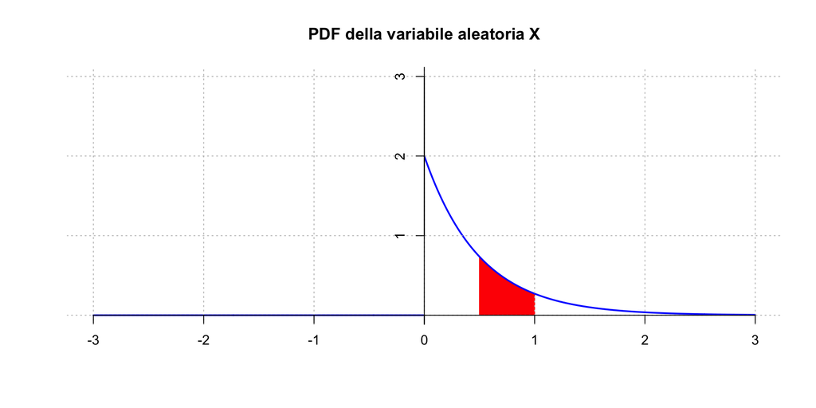

1. $X$ ha valor medio ##ANSWER1##
2. $X$ ha deviazione standard ##ANSWER2##
3. La probabilità rappresentata dall’area della porzione di grafico in rosso è pari a ##ANSWER3##
4. $E(3X^2) = $ ##ANSWER4##
5. $Var(3X) = $ ##ANSWER5##

#### Soluzione

Dal grafico proposto osserviamo che la varabile aleatoria $X$ è un’esponenziale, quindi la sua PDF è data da
$$\begin{equation*}
f(x) = \begin{cases} \lambda e^{-\lambda x} \quad x \geq 0\\
0 \quad x <0
\end{cases}
\end{equation*}$$
pertanto il valore in corrispondenza di $x=0$, ovvero 2, ci restituisce il valore del parametro $\lambda$.

1. In una distribuzione esponenziale il valor medio corrisponde all’inverso del parametro $\lambda$, dunque $X$ ha valor medio uguale a 0.5.
2. Per una v.a. esponenziale, la varianza e pari a $1/ \lambda^2$, dunque la deviazione standard è pari a 0.5.
3. La probabilità rappresentata in rosso è pari a 0.2325, per calcolarla usiamo il seguente comando su R:

   ```r
    pexp(1,2) - pexp(0.5,2)
   ```

4. Sfruttando la linearità del valor medio si ottiene $\mathbb{E}(3X^2) = 3\mathbb{E}(X^2)$. Ricordando la definizione di varianza di una v.a. abbiamo
   $$\begin{equation*}
   Var(X)= \mathbb{E}[X^2] - \mathbb{E}[X]^2 \quad \Rightarrow \quad
   \mathbb{E}[X^2] = Var(X) + \mathbb{E}[X]^2
   \end{equation*}$$
   e quindi dai risultati dei punti precedenti otteniamo 1.5.
5. Ricordando che vale $Var(aX)=a^2Var(X)$ si ottiene che $Var(3X) = 2.25$.

## Esercizio

#### Importante

Approssimate, se necessario, i risultati alla **quarta cifra decimale**.

Hai comprato 6 belle lampade da giardino. Ciascuna di esse ha tempo di funzionamento (in giorni) Esponenziale di media 420 giorni. Si considerino le durate delle vite delle diverse lampade indipendenti.

1. Con quale probabilità una lampada funziona più di 380 giorni? ##ANSWER1##
2. Con quale probabilità una lampada funziona per un tempo compreso tra 380 e 470 giorni sapendo che sta funzionando correttamente da 360 giorni? ##ANSWER2##
3. La varianza della durata di vita di una delle tue lampade è pari a ##ANSWER3##
4. Con quale probabilità tra 380 giorni meno di ($<$) 4 delle tue lampade si sono rotte? ##ANSWER4##

#### Soluzione

Sia $X$ la variabile aleatoria che resitituisce il tempo di funzionamento di una lampadina. Sappiamo che $X$ è una v.a. esponenziale, dunque ha densità (PDF):

$$\begin{equation*}
f(x) = \lambda e^{-\lambda x}, \; x \geq 0
\end{equation*}$$

dove $\lambda$ è pari all’inverso del valor medio, e quindi, in questo caso pari a $1/420$.

La funzione di distribuzione cumulata (CDF) è:

$$\begin{equation*}
P(X \leq y) = F_X(y) = \int_{0}^{y} f(x) dx
\end{equation*}$$

Possiamo calcolare $F_X(y)$ su R utilizzando il seguente comando:

```r
  pexp(y,lambda)
```

1. La probabilità che una lampada funzioni per più di 380 giorni è pari a:
   $$\begin{equation*}
   P(X > 380) = 1- P(X \leq 380) = 1- F_X(380)= 1 -
   \text{pexp}(380,1/420) = 0.4046
   \end{equation*}$$
2. La probabilità richiesta si può trovare utilizzando la definizione della probabilità condizionata, ed è data da:
   $$\begin{align*}
   P(380 < X < 470|X>360) &= \frac{P(380 < X < 470,
   X>360)}{P(X>360)} = \frac{P(380 < X < 470)}{1-P(X \leq360)}
   =\\
   & =\frac{P(X < 470)- P(X < 380)}{1-P(X \leq360)} =
   \frac{\text{pexp}(470,1/420) - \text{pexp}(380,1/420)}{1 -
   \text{pexp}(360,1/420)} =\\
   &= 0.1839
   \end{align*}$$
3. Per rispondere a questa domanda basta ricordare che la varianza di una v.a. esponenziale di parametro $\lambda$ è pari a $1/\lambda^2$ e quindi in questo caso è pari a 1.764^{5}.
4. La probabilità che tra 380 giorni meno di ($<$) 4 delle tue lampade si sono rotte si può riformulare come risultato di $6$ prove ripetute di tipo bernoulliano (una prova per ogni lampadina). Più precisamente sia $Y$ il numero di lampadine che tra 380 giorni risultano rotte, vogliamo calcolare $P(Y < 4)$. Quindi $Y \sim Binomiale(6,p)$ dove $p$ è la probabilità che la lampadina risulti rotta dopo 380 giorni, ovvero $p=P(X \leq 380)$ cioè la probabilità che il tempo di funzionamento sia inferiore o uguale a 380 giorni. Dal punto 1 allora abbiamo che $p = 1 - 0.4046$. Dunque possiamo calcolare $P(Y < 4)$ come:
   $$\begin{align*}
   &\text{> psucc = pexp(}380\text{,} 0.002381 )\\
   &\text{> pbinom(} 3,6\text{, psucc)}
   \end{align*}$$
   ottenendo un valore pari a 0.4653.